# Assignment 7

Hierarchical model in Stan

Author

anonymous

**Setup**

*This block will only be visible in your HTML output, but will be hidden when rendering to PDF with quarto for the submission.* **Make sure that this does not get displayed in the PDF!**

The following loads several needed packages:

```r
library(aaltobda)
library(bayesplot)
library(cmdstanr)
library(dplyr)
library(ggplot2)
library(ggdist) # for stat_dotsinterval
library(posterior)
if(!require(brms)){
    install.packages("brms")
    library(brms)
}
```

```
Loading 'brms' package (version 2.16.3). Useful instructions
can be found by typing help('brms'). A more detailed introduction
to the package is available through vignette('brms_overview').
```

```r
# Set more readable themes with bigger font for plotting packages.
ggplot2::theme_set(theme_minimal(base_size = 14))
bayesplot::bayesplot_theme_set(theme_minimal(base_size = 14))

# This registers CmdStan as the backend for compiling cmdstan-chunks.
check_cmdstan_toolchain(fix = TRUE, quiet = TRUE)
register_knitr_engine(override = FALSE)
```

# 1 Hierarchical Model: Chicken Data with Stan (6p)

## 1.1 Choosing a weakly informative prior by intuition

### 1.1.3 (e)

$\mu_0 \text{~} N(1750, 2000)$

## 1.2 Choosing a weakly informative prior using external references

### 1.2.1 (f)

```r
pnorm(1000, 670, 120)
```

```
[1] 0.9970202
```

We end up with a standard deviation for the prior of 120.

### 1.2.2 (i)

$\mu_0 \text{~} N(670, 120)$

## 1.3 Non-normal priors

### 1.3.1 (j)

Normal priors can make no sense in the case of variables that are bounded (since Normal goes from -inf to inf). For example, the variance prior should probably not follow a normal distribution. Another example could be parameters that need to be from 0 to 1 for example.

## 1.4 Modeling diet effects on chicken weight

**Data inside, don’t peek before you have set your priors!**

**Have you set your priors?**

```r
data("ChickWeight")

Chick12 <- ChickWeight %>% filter(Time == 12)

head(Chick12)
```

```
Grouped Data: weight ~ Time | Chick
  weight Time Chick Diet
1    106   12     1    1
2    122   12     2    1
3    115   12     3    1
4    102   12     4    1
5    141   12     5    1
6    141   12     6    1
```

**Model fitting**

*This block will only be visible in your HTML output, but will be hidden when rendering to PDF with quarto for the submission.* **Make sure that this does not get displayed in the PDF!**

To run Stan for that model, simply use:

```r
stan_data <- list(
  N_observations = nrow(Chick12),
  N_diets = length(unique(Chick12$Diet)),
  diet_idx = Chick12$Diet,
  weight = Chick12$weight
)

model_separate <- cmdstan_model(stan_file = "additional_files/assignment7/chickens_separate.stan")

# Sampling from the model happens here:
fit_separate <- model_separate$sample(data = stan_data, refresh=0,
                                      show_messages=FALSE)
```

```
Running MCMC with 4 sequential chains...

Chain 1 finished in 0.3 seconds.
Chain 2 finished in 0.2 seconds.
Chain 3 finished in 0.3 seconds.
Chain 4 finished in 0.3 seconds.

All 4 chains finished successfully.
Mean chain execution time: 0.3 seconds.
Total execution time: 1.6 seconds.
```

Fit objects by default print a summary of the draws obtained. These are **NOT** the results you would expect to turn in your report. You will need to change the priors in the code for the separate model.

```r
fit_separate
```

```
     variable    mean  median    sd   mad      q5     q95 rhat ess_bulk
 lp__         -488.91 -488.55  2.02  1.83 -492.74 -486.30 1.00     1647
 mean_diet[1]   73.05   73.62  8.36  8.05   58.45   86.09 1.00     3217
 mean_diet[2]   50.76   50.64 10.56 10.50   33.31   68.12 1.00     3368
 mean_diet[3]   52.02   51.81 10.94 10.86   34.20   70.03 1.00     3124
 mean_diet[4]   53.00   52.77 11.08 11.23   35.38   71.62 1.00     3158
 sd_diet[1]     30.38   30.09  3.99  4.01   24.31   37.29 1.00     3292
 sd_diet[2]     40.10   39.93  4.60  4.45   32.69   47.80 1.00     3086
 sd_diet[3]     42.65   42.56  4.83  4.73   34.96   50.92 1.00     3417
 sd_diet[4]     43.63   43.52  4.99  5.04   35.58   52.09 1.00     3048
 weight_pred    52.48   53.63 44.66 43.75  -25.27  123.49 1.00     3815
 ess_tail
     2688
     2691
     2903
     2985
     2815
     2745
     2587
     2720
     2314
     3850

 # showing 10 of 12 rows (change via 'max_rows' argument or 'cmdstanr_max_rows' option)
```

Quick model convergence check (as in assignment 6):

```r
fit_separate$cmdstan_diagnose()
```

```
Processing csv files: C:/Users/Franco/AppData/Local/Temp/RtmpkXAZfX/chickens_separate-202304121448-1-1e76cc.csv, C:/Users/Franco/AppData/Local/Temp/RtmpkXAZfX/chickens_separate-202304121448-2-1e76cc.csv, C:/Users/Franco/AppData/Local/Temp/RtmpkXAZfX/chickens_separate-202304121448-3-1e76cc.csv, C:/Us…

Checking sampler transitions treedepth.
Treedepth satisfactory for all transitions.

Checking sampler transitions for divergences.
No divergent transitions found.

Checking E-BFMI - sampler transitions HMC potential energy.
E-BFMI satisfactory.

Effective sample size satisfactory.

Split R-hat values satisfactory all parameters.

Processing complete, no problems detected.
```

### 1.4.1 (k)

**Pooled model:**
$$w_{ij} \text{~} N(\mu, \sigma)$$
$$\mu \text{~} N(670,120)$$
$$\sigma \text{~} Uniform(0,100)$$

$$\mu_0 \text{~} N(\mu, \tau)$$
$$\mu \text{~} Uniform(0,800)$$
$$\tau \text{~} Uniform(0,100)$$

The pooled model states that each chicken weight comes from a common normal distribution for all of them, no matter the diet. That Normal distribution has priors for mu and sigma.

I had to play a bit with priors to make it work, specially to have logical results for the pooled and hierarchical model.My priors based on data were really off.  
Also, the separate model has been kept with the bad priors.  
I tried modifying priors for the separate model and I got convincing results -> mean for diet 4 in the hierarchical model being something in between the mean for the pooled model and the separate one.  
With the current bad priors that doesn’t happen because the separate model is really shrunk towards the prior.

**Pooled Model**:

```
data {
  int<lower=0> N_observations;
  int<lower=0> N_diets;
  array[N_observations] int diet_idx; // Pair observations to their diets.
  vector[N_observations] weight;
}

parameters {
  // Average weight of chicks no matter the diet
  real mean_diet;

  // Standard deviation of weights observed among chicks no matter the diet.
  real<lower=0> sd_diet;
}

model {
  // Priors
  // These look bad. I need to think about these again.

    mean_diet ~ normal(670, 120);
    sd_diet ~ uniform(0,100);

  // Likelihood
    weight ~ normal(mean_diet, sd_diet);
  // Best practice would be to write the likelihood without the for loop as:
  // weight ~ normal(mean_diet[diet_idx], sd_diet[diet_idx]);
}

generated quantities {
  real weight_pred;
  real mean_five;

  // Sample from the (posterior) predictive distribution
  weight_pred = normal_rng(mean_diet, sd_diet);
}
```

**Hierarchical Model**:

```
data {
  int<lower=0> N_observations;
  int<lower=0> N_diets;
  array[N_observations] int diet_idx; // Pair observations to their diets.
  vector[N_observations] weight;
}

parameters {
  // Average weight of chicks with a given diet.
  vector[N_diets] mean_diet;

  // Standard deviation of weights observed among chicks sharing a diet. Shared deviation for all diets.
  real<lower=0> sd_diet;

  real<lower=0> mean_general;
  real<lower=0> sd_general;

}

model {
  // Priors
  // These look bad. I need to think about these again.

    mean_general ~ uniform(0,800);
    sd_general ~ uniform(0,100);
    sd_diet ~ uniform(0,100);

  for (diet in 1:N_diets) {
    mean_diet[diet] ~ normal(mean_general, sd_general);
  }

  // Likelihood
  for (obs in 1:N_observations) {
    weight[obs] ~ normal(mean_diet[diet_idx[obs]], sd_diet);
  }

  // Best practice would be to write the likelihood without the for loop as:
  // weight ~ normal(mean_diet[diet_idx], sd_diet[diet_idx]);
}

generated quantities {
  real weight_pred;
  real mean_five;

  // Sample from the (posterior) predictive distribution of the fourth diet.
  weight_pred = normal_rng(mean_diet[4], sd_diet);

  // Construct samples of the mean of the fifth diet.
  // We only have the prior...
  mean_five = normal_rng(0, 10);
}
```

**Model fitting and data preparation**

*This block will only be visible in your HTML output, but will be hidden when rendering to PDF with quarto for the submission.* **Make sure that this does not get displayed in the PDF!**

```r
model_pooled <- cmdstan_model(stan_file = "additional_files/assignment7/chickens_pooled.stan")

# Sampling from the model happens here:
fit_pooled <- model_pooled$sample(data = stan_data, refresh=0,
                                      show_messages=FALSE)
```

```
Running MCMC with 4 sequential chains...

Chain 1 finished in 0.0 seconds.
Chain 2 finished in 0.0 seconds.
Chain 3 finished in 0.0 seconds.
Chain 4 finished in 0.0 seconds.

All 4 chains finished successfully.
Mean chain execution time: 0.0 seconds.
Total execution time: 0.7 seconds.
```

```r
model_hierarchical <- cmdstan_model(stan_file = "additional_files/assignment7/chickens_hierarchical.stan")

# Sampling from the model happens here:
fit_hierarchical <- model_hierarchical$sample(data = stan_data, refresh=0,
                                      show_messages=FALSE)
```

```
Running MCMC with 4 sequential chains...

Chain 1 finished in 0.3 seconds.
Chain 2 finished in 0.2 seconds.
Chain 3 finished in 0.2 seconds.
Chain 4 finished in 0.4 seconds.

All 4 chains finished successfully.
Mean chain execution time: 0.3 seconds.
Total execution time: 1.4 seconds.
```

Below, we collect the corresponding samples from the three models into a shared data frame using the `extract_variable` function. This makes plotting the samples in a single plot easier.

```r
# Expect the same number of samples from each model.
n_samples <- nrow(fit_hierarchical$sampler_diagnostics(format = "matrix"))

# Collect samples and the model used to a data frame.
posterior_mean_diet_4 <- data.frame(
  model_name = rep(c("Separate", "Pooled", "Hierarchical"),
              each = n_samples),
  mean_diet_4 = c(
   extract_variable(fit_separate, "mean_diet[4]"),
   extract_variable(fit_pooled, "mean_diet"),
   extract_variable(fit_hierarchical, "mean_diet[4]")
  ))

predicted_weight_diet_4 <- data.frame(
  model_name = rep(c("Separate", "Pooled", "Hierarchical"),
              each = n_samples),
  predicted_weight = c(
   extract_variable(fit_separate, "weight_pred"),
   extract_variable(fit_pooled, "weight_pred"),
   extract_variable(fit_hierarchical, "weight_pred")
  ))

# Collect samples and the model used to a long data frame.
posterior_mean_diet_5 <- data.frame(
  model_name = rep(c("Separate", "Pooled", "Hierarchical"),
    each = n_samples
  ),
  mean_diet_5 = c(
    extract_variable(fit_separate, "mean_five"),
    extract_variable(fit_pooled, "mean_diet"),
    extract_variable(fit_hierarchical, "mean_five")
  )
)

# Mean observed weight per diet, these help to compare the posteriors to data.
diet_means <- sapply(
  1:4, function(diet) mean(Chick12[Chick12$Diet == diet, "weight"])
)
```

### 1.4.2 (m)

Ideally the hierarchical model should be somewhere in between the separate and pooled model but it’s not the case because of the bad priors on the separate model.  
Apart from that we can see greater dispersion in the posterior for the separate model, a bit less in the hierarchical one and much less in the pooled one.  
The pooled model is not as close as the hierarchical one to the actual mean diet, which makes sense based on the pooling (other diets play a larger role).  
The separate model is clearly wrong as it should be centered close to the actual mean but again, the priors are too strong for the data avaialable.

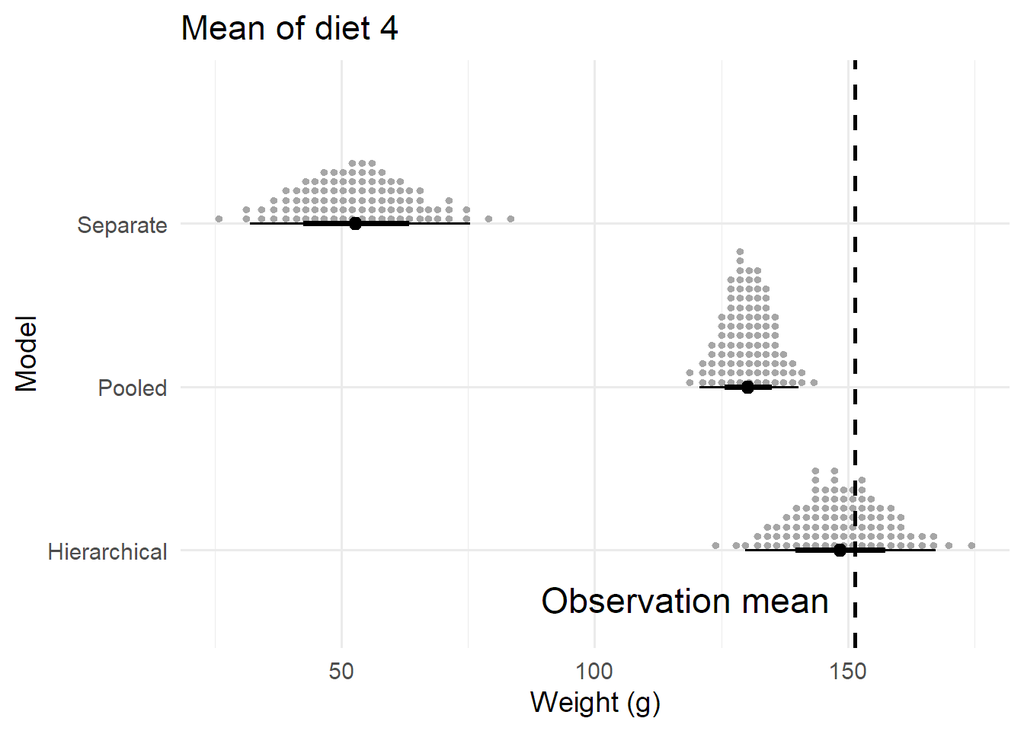

Posterior distribution of the mean weight of chicks consuming diet 4.

```r
ggplot(posterior_mean_diet_4, aes(x = mean_diet_4, y = model_name)) +
  stat_dotsinterval(quantiles = 100, scale = .9) +
  vline_at(diet_means[4], size = 1, linetype = "dashed") +
  # Annotate the vline from above.
  annotate("text", label = "Observation mean", x = diet_means[4] - 5, y = .7,
           hjust = "right", size = 6) +
  # Add title and axis labels. One line to make everything so much more clear!
  labs(
    title = "Mean of diet 4",
    x = "Weight (g)",
    y = "Model"
  )
```

### 1.4.3 (n)

The predictive distribution for the diet 4 overlaps much more the different posteriors. The mean is the same as in the previous plot but we can see much larger dispersion on the possible values. Even the separate model has some draws close to the actual mean, but also some negative draws…  
The distributions have larger tails admitting some “far” away draws but most of the mass for both the pooled and hierarchical model are in a decent range between ~100 and 200 grams and no negative values.

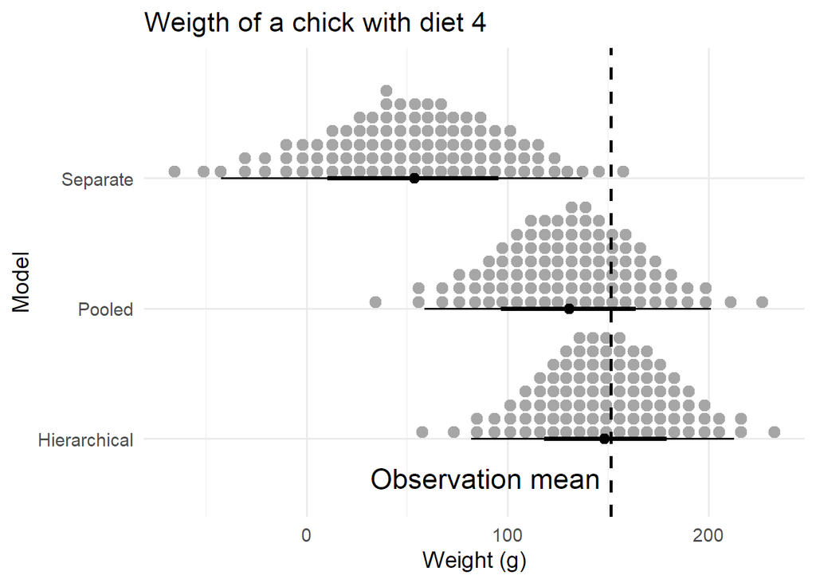

The (posterior) predictive distribution of the weigth of a chick consuming diet 4.

```r
ggplot(predicted_weight_diet_4, aes(x = predicted_weight, y = model_name)) +
  stat_dotsinterval(quantiles = 100, scale = .9) +
  vline_at(diet_means[4], size = 1, linetype = "dashed") +
  # Annotate the vline from above.
  annotate("text", label = "Observation mean", x = diet_means[4] - 5, y = .7,
           hjust = "right", size = 6) +
  # Add title and axis labels. One line to make everything so much more clear!
  labs(
    title = "Weigth of a chick with diet 4",
    x = "Weight (g)",
    y = "Model"
  )
```

### 1.4.4 (o)

The separate model has no data to estimate a new fifth diet and so we only can sample from the prior. In this case, the bad prior, a Normal(0,10) as it is shown in the plot.  
For the pooled model we sample from the pooled distribution of means, the same we did for diet 4. All diets share a distribution.  
For the hierarchical model we can sample a new diet mean from the super population.  
It’s a pretty wide distribution. The mode and most part of the mass is above 100 grams which is fine but the tails are heavy and there are extreme value, including a few negative draws.

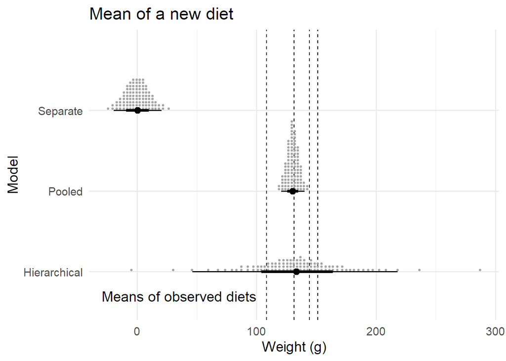

Posterior distribution of the mean weight of chicks consuming the new diet 5 not seen before.

```r
ggplot(posterior_mean_diet_5, aes(x = mean_diet_5, y = model_name)) +
  # Draw the mean of each diet from the data as a dashed vertical line.
  vline_at(diet_means, size = .5, linetype = "dashed") +
  # dotsinterval gives mean, 50%, and 90% intervals + dotsplot with each dot
  # representing 1% of data (quantiles = 100).
  stat_dotsinterval(quantiles = 100, scale = .9) +
  # Annotate the vline from above.
  annotate(geom = "text", label = "Means of observed diets", y = .7, x = 100,
           hjust = "right", size = 5, family = "sans") +
  # Add title and axis labels. One line to make everything so much more clear!
  labs(title = "Mean of a new diet",
       x = "Weight (g)",
       y = "Model")
```

### 1.4.5 (p)

**Separate model** For the separate model, the 90% credible interval of the mean of the diet 4 is the following:

```r
model  = posterior_mean_diet_4 %>% filter(model_name == "Separate" )

quantile(model$mean_diet_4,probs=c(0.05, 0.95))
```

```
      5%      95%
35.38390 71.62072
```

**Pooled model** For the pooled model, the 90% credible interval of the mean of the diet 4 is the following:

```r
model  = posterior_mean_diet_4 %>% filter(model_name == "Pooled" )

quantile(model$mean_diet_4,probs=c(0.05, 0.95))
```

```
      5%      95%
122.2207 138.3813
```

**Hierarchical model** For the Hierarchical model, the 90% credible interval of the mean of the diet 4 is the following:

```r
model  = posterior_mean_diet_4 %>% filter(model_name == "Hierarchical" )

quantile(model$mean_diet_4,probs=c(0.05, 0.95))
```

```
      5%      95%
133.1306 164.4764
```

# 2 Hierarchical model with BRMS (3p)

### 2.0.1 (a)

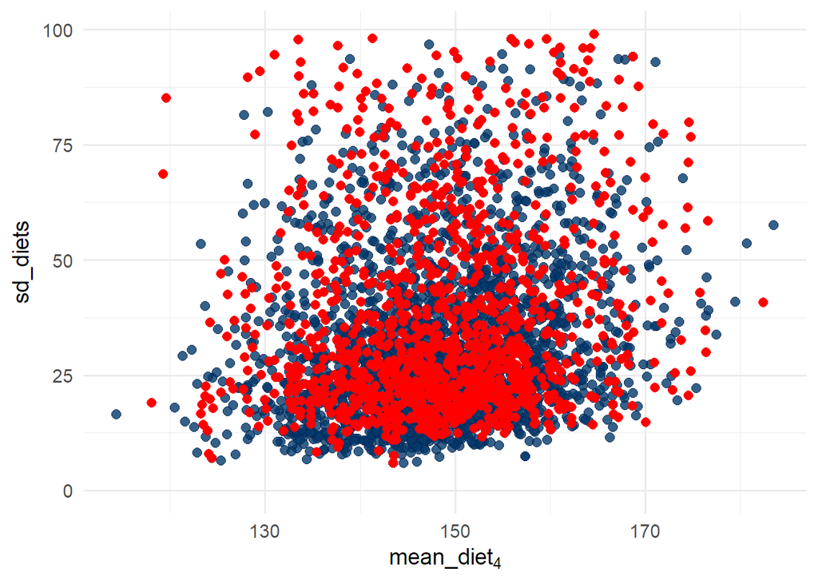

```r
bayesplot::mcmc_scatter(x = fit_hierarchical$draws(variables = c("mean_diet[4]", "sd_general")),
                        np = nuts_params(fit_hierarchical)) +
  scale_y_log10() +
  labs(x = expression(mean_diet[4]), y = expression(sd_diets)) +
  ylim(c(0,NA))
```

There is plenty of possible divergent transitions, all over the scatterplot and not in a particular region.

### 2.0.2 (b)

**Fit brms model**

*This block will only be visible in your HTML output, but will be hidden when rendering to PDF with quarto for the submission.* **Make sure that this does not get displayed in the PDF!**

```r
brms_fit = brm(
  weight ~ 1 + (1 | Diet),
  data=Chick12,
  prior=c(
    # REPLACE WITH YOUR PRIOR FOR THE INTERCEPT
    prior(uniform(0,800), class="Intercept"), # prior for mu_0
    # REPLACE WITH YOUR PRIOR FOR SIGMA
    prior(uniform(0,100), class="sigma"),     # prior for sigma
    # REPLACE WITH YOUR PRIOR FOR SD
    prior(uniform(0,100), class="sd")         # prior for tau
  ),
  backend = "cmdstanr",
  save_pars = save_pars(manual = c("z_1[1,4]"))
)
```

```
Running MCMC with 4 sequential chains...
```

[output not shown]

[output not shown]

[output not shown]

[output not shown]

[output not shown]

[output not shown]

[output not shown]

[output not shown]

[output not shown]

[output not shown]

[output not shown]

[output not shown]

Because `brms` is a bit chatty, suppress it’s output in the PDF using the block above, but copy the code you executed into the code block below, which doesn’t execute:

```r
brms_fit = brm(
  weight ~ 1 + (1 | Diet),
  data=Chick12,
  prior=c(
    # REPLACE WITH YOUR PRIOR FOR THE INTERCEPT
    prior(uniform(0,800), class="Intercept"), # prior for mu_0
    # REPLACE WITH YOUR PRIOR FOR SIGMA
    prior(uniform(0,100), class="sigma"),     # prior for sigma
    # REPLACE WITH YOUR PRIOR FOR SD
    prior(uniform(0,100), class="sd")         # prior for tau
  ),
  backend = "cmdstanr",
  save_pars = save_pars(manual = c("z_1[1,4]"))
)
```

[output not shown]

[output not shown]

[output not shown]

[output not shown]

[output not shown]

[output not shown]

[output not shown]

[output not shown]

[output not shown]

[output not shown]

[output not shown]

[output not shown]

[output not shown]

[output not shown]

[output not shown]

[output not shown]

[output not shown]

[output not shown]

[output not shown]

[output not shown]

[output not shown]

[output not shown]

### 2.0.3 (c)

```r
# Draws for mu_4
mu_4 = posterior_epred(brms_fit, newdata = data.frame(Diet=4))

# To display accurate digits
# MCSE for the mean
print(posterior::mcse_mean(mu_4))
```

```
[1] 0.1819376
```

```r
# To display accurate digits
# MCSE for the quantiles
print(posterior::mcse_quantile(mu_4,probs=c(0.05, 0.95)))
```

```
 mcse_q5 mcse_q95
0.329385 0.441550
```

```r
# Compute the mean, and quantiles. Remember to round your answers accordingly.
# ...
print(paste0("mean: ", round(mean(mu_4),0)))
```

```
[1] "mean: 148"
```

```r
print("90% credible interval:")
```

```
[1] "90% credible interval:"
```

```r
print(round(quantile(mu_4,probs=c(0.05, 0.95),0)))
```

```
 5% 95%
132 165
```

The results are virtually the same. I got divergent chains even with brms. Maybe it’s a problem with the priors used? Not sure really.

### 2.0.4 (d)

### 2.0.5 Scatterplot for non-centered parametrization

Due the non-centered parametrization, we need to transform compute the $\mu_d$ term as the sum of the population intercept and the group specific deviation from the intercept. You can choose which diet to plot by modifying the `d` integer in `r_Diet[d,Intercept]`.

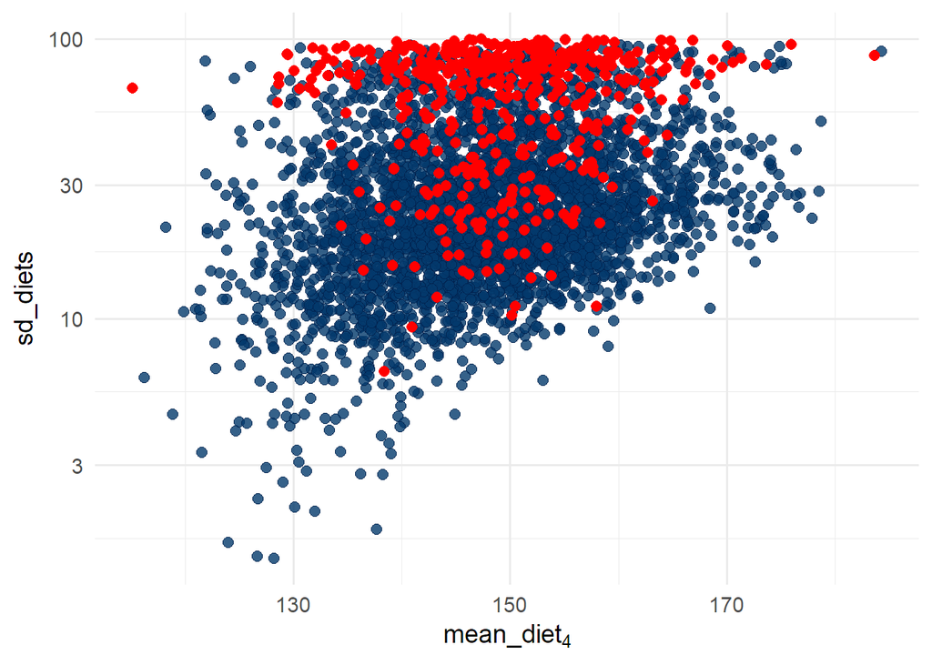

```r
draws = as_draws_df(brms_fit) %>%
  posterior::mutate_variables(mean_diet_4 = `r_Diet[4,Intercept]` + b_Intercept)

bayesplot::mcmc_scatter(draws,
                        pars = c("mean_diet_4", "sd_Diet__Intercept"),
                        np = nuts_params(brms_fit)) +
  scale_y_log10() +
  xlab(expression(mean_diet[4])) +
  ylab(expression(sd_diets))
```

Still a lot of divergences although they seem more localized in the upper bound of the standard deviations. Still across all the values of the mean diet.

### 2.0.6 (e)

In brms the divergent transitions occur much more in the higher values of Tau while in Stan they occurred more spread but with highest chance in the lower values of Tau.

The centered parametrization had problems sampling all over the parameter space although specially in the lower values of Tau.  
The non-centered parametrization has issues in the highest values of Tau but in the rest it seems to be more stable.